# Exam 3

You can download the combined lecture notes for this module at: http://asta.math.aau.dk/dan/2017f/asta/?file=handouts/module-C.pdf

Remember to load the `mosaic` package first:

```r
library(mosaic)
```

## House prices

In this exercise you will study the data described in Agresti EXAMPLE 9.10.

You are studying house sales in Gainesville, Florida, where among other things the data contain the selling price (`Price`), property taxes (`Taxes`) and house size (`Size`).

Read in the data:

```r
HousePrices <- read.table("http://asta.math.aau.dk/dan/static/datasets?file=HousePrice.dat", header=TRUE)
head(HousePrices)
```

```
##   Taxes  Price Size
## 1  3104 279900 2048
## 2  1173 146500  912
## 3  3076 237700 1654
## 4  1608 200000 2068
## 5  1454 159900 1477
## 6  2997 499900 3153
```

- **Make a relevant plot of the variables** and discuss how they are related.

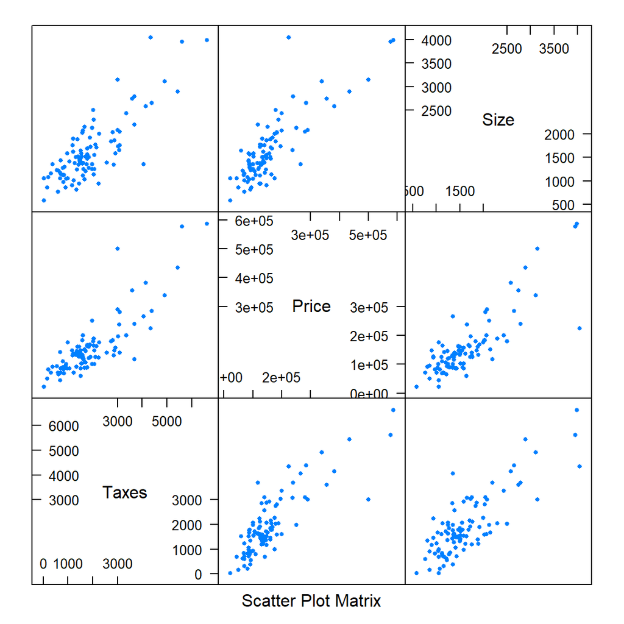

*we can see that the 3 variables are highly related to each other in a sense that they make a more or less a linear correlation. AS one of the variables increase the other one also, so we expect to have high values of correlation between variables*

- **Explain the concept of correlation** and determine whether there is significant positive **correlation between `Taxes` and `Size`**.

*The Correlation measures the strength of dependence between the variable y and variable x. In other words refers to how close two variables are to having a linear relationship with each other.*

*Lets take x and y as parameters that could be correlated.* *Thus,* $s_y$ *and* $s_x$ *denote the sample standard deviation of y and x.* *The corresponding prediction equation is then*
$$\hat y_t = \frac{a}{s_y}+\frac{s_x}{s_y}bx_t$$
*Then, the standardized regression coefficient, also called the correlation is:*
$$r = \frac{s_x}{s_y}b$$
*In this model we can calculate the correlation of Taxes and Size by means of the next command:*

```r
cor(HousePrices)
```

```
##           Taxes     Price      Size
## Taxes 1.0000000 0.8419802 0.8187958
## Price 0.8419802 1.0000000 0.8337848
## Size  0.8187958 0.8337848 1.0000000
```

*As could be deduced before plotting, there are a strong relation between Prices and Taxes, and also between Size and Prices. This graphic also shows that there is a correlation between Size and Taxes.* *Some values are extremes, and coud be removed to get a more accurate model*

*using the next command a correlation test has been made:*

```r
cor.test(~Taxes+Size, data=HousePrices)
```

```
##
##  Pearson's product-moment correlation
##
## data:  Taxes and Size
## t = 14.119, df = 98, p-value < 2.2e-16
## alternative hypothesis: true correlation is not equal to 0
## 95 percent confidence interval:
##  0.7416554 0.8745614
## sample estimates:
##       cor
## 0.8187958
```

*We can say watching the p-value that our zero hypothesis is rejected due to the value is bellow %5… which accomplishes the alternative hypothesis.It also can be stated that there is a significant (p=2.2e-16) correlation between taxes and size.*

*On te other hand, we can say with a 95% of confidence level that the correlation will be around 0.7416 and 0.8745.*

**Fit a multiple regression model** with **Price as the response** variable and **`Taxes` and `Size` as predictors**.

```r
model <- lm( Price ~ Taxes+Size, data = HousePrices )
model
```

```
##
## Call:
## lm(formula = Price ~ Taxes + Size, data = HousePrices)
##
## Coefficients:
## (Intercept)        Taxes         Size
##   -28608.74        39.60        66.51
```

**Explain the output of the model**

where `model` is the fitted multiple regression model. This explanation should as a minimum include:

*Model without interactions:*

$$y = \alpha+\beta_1x_{1}+\beta 2·{x_2}+e$$

```r
summary(model)
```

```
##
## Call:
## lm(formula = Price ~ Taxes + Size, data = HousePrices)
##
## Residuals:
##     Min      1Q  Median      3Q     Max
## -188027  -26138     347   22944  200114
##
## Coefficients:
##               Estimate Std. Error t value Pr(>|t|)
## (Intercept) -28608.744  13519.096  -2.116   0.0369 *
## Taxes           39.601      6.917   5.725 1.16e-07 ***
## Size            66.512     12.817   5.189 1.16e-06 ***
## ---
## Signif. codes:  0 '***' 0.001 '**' 0.01 '*' 0.05 '.' 0.1 ' ' 1
##
## Residual standard error: 48830 on 97 degrees of freedom
## Multiple R-squared:  0.7722, Adjusted R-squared:  0.7675
## F-statistic: 164.4 on 2 and 97 DF,  p-value: < 2.2e-16
```

- **Calculation of `t value`** and determination and **interpretation of p-value**.

*The t-value is calculated as shown:*
$$t = \frac{\text Estimate}{\text {Standard Error}}$$

```r
P = 2*pdist("t", q = 5.72, df = 97)
```

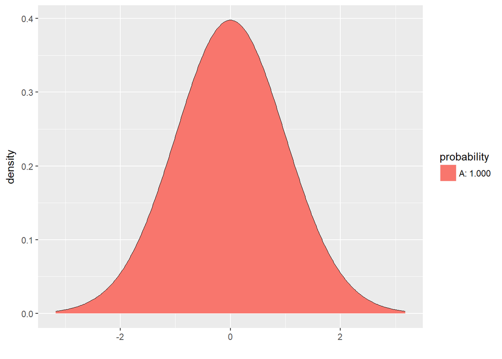

```r
P
```

```
## [1] 2
```

- **Degrees of freedom**

*In this case, we have 100 observations and 3 variables. Thus, the model have 100-3=97 degrees of freedom.*

- **Interpretation of `Multiple R-squared`.**

*The Multiple R-Squared means the relative reduction in prediction error. For calculating the R-squared there is a need to calculate to variables the TSS and SSE. The Tss is the squarred error between the observation and the mean, and the SSE, which is the squarred error between the regression line and the observation.*

$$R^2 = \frac{TSS-SSE}{TSS} \quad \text {}$$

- How the table of output can be used to construct **confidence intervals for parameters**.

*We can construct a confidence interval for each parameter by following the next graph.*

```r
t<-qdist("t", p = 0.025, df = 100-3)
```

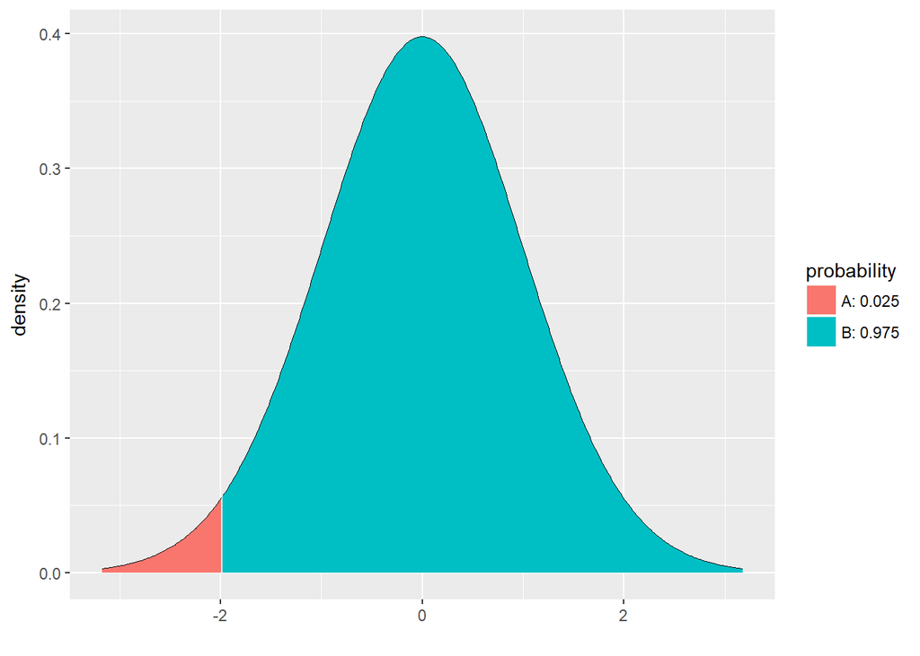

```r
t
```

```
## [1] -1.984723
```

$$\text {for a 95% confidence interval: }\quad t = 1.9847$$

$$\text {for the variable Taxes} \quad (min,max) = b_1 \pm tse_b = 39.601 \pm 1.9847\cdot 6.917 = (25.87, \quad 53.33)$$
$$\text {for the variable Size} \quad (min,max) = b_2 \pm tse_b = 66.512 \pm 1.9847\cdot 12.817 = (41.07, \quad 91.95)$$

*Checking the results with the confint function for a 95% of the confidence level:*

```r
confint(model)
```

```
##                    2.5 %      97.5 %
## (Intercept) -55440.40818 -1777.08054
## Taxes           25.87192    53.32920
## Size            41.07304    91.95066
```

- **Interpretation of F-statistic**

*It shows if the model can be reduced into a single value (the intercept point), because all the predictors are not significant (Null Hypothesis), depending on the p-value.*

$$F = \frac{(n-k-1)R^2}{k(1-R^2)} = \frac{(100-2-1)\cdot0.7722}{2(1-0.7722)} = 164.4$$

```r
1 - pdist("f", 164.4, df1=2, df2=97, plot = FALSE)
```

```
## [1] 0
```

Finally, you have to investigate whether or not there is an **interaction between the effect of `Taxes` and the effect of `Size` as predictors of `Price`**.

*interaction model equation:*

$$y = \alpha+\beta_1x_{1}+\beta_2·{x_2}+\beta_3·{x_1}·{x_2}$$

```r
model2 <- lm( Price ~ Taxes*Size, data = HousePrices )
summary(model2)
```

```
##
## Call:
## lm(formula = Price ~ Taxes * Size, data = HousePrices)
##
## Residuals:
##     Min      1Q  Median      3Q     Max
## -202902  -23642    -224   20081  213409
##
## Coefficients:
##              Estimate Std. Error t value Pr(>|t|)
## (Intercept) 2.396e+04  2.450e+04   0.978   0.3305
## Taxes       1.991e+01  1.026e+01   1.941   0.0551 .
## Size        3.329e+01  1.806e+01   1.844   0.0683 .
## Taxes:Size  1.036e-02  4.072e-03   2.544   0.0126 *
## ---
## Signif. codes:  0 '***' 0.001 '**' 0.01 '*' 0.05 '.' 0.1 ' ' 1
##
## Residual standard error: 47510 on 96 degrees of freedom
## Multiple R-squared:  0.7866, Adjusted R-squared:  0.7799
## F-statistic: 117.9 on 3 and 96 DF,  p-value: < 2.2e-16
```

*df=n-4=100-4=96, we have for parameters (x1,x1,x1x2,y)*

*Looking at the predictors in this model, it seems that the single predictors are not needed for explaining the model, but only the multiple predictor.*

*Again we can see that the t value is calculated by the estimate divided the sandard error.*

*if you remove one you have to run the model again and see the results because the p values will change and maybe you can reject one variable or not. don know, run it !*